# 제목:The influence of education on their marriage decision：Evidence from China

## 1.배경및목적

### 1.결혼

2014년 통계 데이터에서 중국의 결혼율은 해마다 하락하고 있고 만혼 (늦게) 하거나 결혼을 하지 않는 등 현상은 갈수록 흔해지고 있다.결혼은 생육과 밀접히 관련되여있는 결혼율이 낮아지면 인구출생율에 영향을 주게 되고 경제와 사회의 발전에도 영향을 미치게 된다. 2018년 중국에서 상하이 (上海)와 저장 (浙江)의 결혼율은 각각 4.4%, 5.9 %로 하위권에서 차지하고 있다 . 광둥 (廣東), 베이징 (北京), 톈진 (天津) 등 지역의 결혼율도 낮은 편이다. 결혼율이 가장 높은 몇몇 지역은 티베트（西藏）, 칭하이（青海）, 안후이（安徽）, 구이저우（贵州） 등의 미발달 지역이다.구이저우는 2018년 결혼율이 11.1%에 달해 전국에서 상위권에 올랐다.

2020년에 출판된 중국청년발전보고서에서는 1985년부터 2015년까지 남녀 초혼연령의 변화가 모두 3살가량 늘어났다. '고령 남녀 독신'은 사실 세계적 현대화의 결과이고 지역적 현상이 아니다.서방 선진국에서는 고령 남녀 독신이 이미 사실이고 보편적으로 받아들여지는 개인 생활 방식이지만, 중국처럼 보편적으로 결혼을 하는 나라에서는 이 집단이 주목을 받고 있다. 2010년 제6차 인구조사에 따르면 30세에서 39세 사이의 미혼 남녀 많는 것을 보일 수 있다. 25부터 29세까지 여성 중 미혼 여성의 비율은20년전의 5배, 30부터3 4세까지 미혼 여성의 비율은 9배 증가했다.연령별 미혼 현상을 성별로 보면 여성은 고학력 · 고능력 · 고소득, 남성은 저학력 · 저능력 · 저소득 순으로 나타났다.

### 2.교육

1986-현재 주로 두개 교육 창책을 실시했다.

## 2.데이터

China family panel studies 데이터베이스를 사용하고 있다. 이 데이터 베이스는 세 단계로 나누어져 있습니다.제가 주로 개인 층명 충 성인 data 이용했다. 개인 차원에서 자격에 부합되는 개인에게는 16세 이하는 어린이 설문을 하고, 16세 이상은 성인 설문지를 한다. 그중에 어린이설문은 대답과 자답 두개 부분으로 나뉘며 10세 이하의 어린이는 그 후견인이 대답부분적 문제에 대답한다. 10살부터 15살까지의 어린이는 보호자가 부분적 문제에 대한 답안을 대필하는외에 본인이 부분적 문제를 완성해야 한다. 기본 정보、형제 자매 상황、교육사、개인 소득、건강、심리적 건강등 포함되다.

```python
import pandas as pd
from pandas import read_csv
import matplotlib.pyplot as plt
import numpy as np
from sklearn.linear_model import LinearRegression
import statsmodels.api as sm
import pandas as pd
```

```python
from google.colab import files
files.upload()
```

```
Saving 2010_data2.csv to 2010_data2.csv
```

[output not shown]

```python
data=pd.read_csv("2010_data2.csv",index_col=None)
data.tail()
```

|  | pid | gender | year | age | hukou | nation | brothersandsisters | app | college | married | after | logincome | fprimary | mprimary |
| --- | --- | --- | --- | --- | --- | --- | --- | --- | --- | --- | --- | --- | --- | --- |
| 1864 | 622000000.0 | 0 | 1980 | 30 | 0.0 | 1 | 1 | 1 | 0 | 1 | 1 | 0.000000 | 0 | 0 |
| 1865 | 622000000.0 | 0 | 1980 | 30 | 0.0 | 1 | 1 | 1 | 1 | 0 | 1 | 9.210441 | 1 | 1 |
| 1866 | 622000000.0 | 0 | 1977 | 33 | 0.0 | 1 | 2 | 0 | 0 | 1 | 0 | 6.908755 | 0 | 1 |
| 1867 | 622000000.0 | 0 | 1981 | 29 | 0.0 | 1 | 1 | 1 | 0 | 1 | 1 | 0.000000 | 1 | 0 |
| 1868 | 622000000.0 | 0 | 1977 | 33 | 0.0 | 1 | 1 | 1 | 0 | 1 | 0 | 0.000000 | 1 | 0 |

```python
data.describe
```

```
<bound method NDFrame.describe of               pid  gender  year  age  ...  after  logincome  fprimary  mprimary
0     110000000.0       0  1978   32  ...      0   9.903538         1         1
1     110000000.0       0  1977   33  ...      0  10.085850         1         1
2     110000000.0       0  1977   33  ...      0   0.000000         1         1
3     110000000.0       0  1981   29  ...      1   8.987322         1         1
4     110000000.0       1  1980   30  ...      1   9.680407         1         1
...           ...     ...   ...  ...  ...    ...        ...       ...       ...
1864  622000000.0       0  1980   30  ...      1   0.000000         0         0
1865  622000000.0       0  1980   30  ...      1   9.210441         1         1
1866  622000000.0       0  1977   33  ...      0   6.908755         0         1
1867  622000000.0       0  1981   29  ...      1   0.000000         1         0
1868  622000000.0       0  1977   33  ...      0   0.000000         1         0

[1869 rows x 14 columns]>
```

## 3.분석 및 결과

### 1.첫 번째 ols

제가 두 가지 연구를 했는데 첫 번째 부분은 일반 회귀 분석이다.통제 변수에는 성별, 외모, 형제자매 수, 아버지 학력이 포함되다.

```python
X = data[["college","gender","app","brothersandsisters","fprimary"]]
X = sm.add_constant(X)
Y = data["married"]

model = sm.OLS(Y,X).fit()
predictions = model.predict(X)
print(model.summary())
```

```
                            OLS Regression Results
==============================================================================
Dep. Variable:                married   R-squared:                       0.043
Model:                            OLS   Adj. R-squared:                  0.041
Method:                 Least Squares   F-statistic:                     16.88
Date:                Sat, 18 Dec 2021   Prob (F-statistic):           2.40e-16
Time:                        11:12:48   Log-Likelihood:                -97.443
No. Observations:                1869   AIC:                             206.9
Df Residuals:                    1863   BIC:                             240.1
Df Model:                           5
Covariance Type:            nonrobust
======================================================================================
                         coef    std err          t      P>|t|      [0.025      0.975]
--------------------------------------------------------------------------------------
const                  0.9224      0.020     45.314      0.000       0.882       0.962
college               -0.0789      0.017     -4.616      0.000      -0.112      -0.045
gender                -0.0791      0.012     -6.646      0.000      -0.102      -0.056
app                    0.0250      0.015      1.656      0.098      -0.005       0.055
brothersandsisters     0.0113      0.004      2.583      0.010       0.003       0.020
fprimary               0.0197      0.014      1.393      0.164      -0.008       0.047
==============================================================================
Omnibus:                     1161.700   Durbin-Watson:                   1.928
Prob(Omnibus):                  0.000   Jarque-Bera (JB):             7820.912
Skew:                          -3.055   Prob(JB):                         0.00
Kurtosis:                      10.944   Cond. No.                         10.5
==============================================================================

Warnings:
[1] Standard Errors assume that the covariance matrix of the errors is correctly specified.
```

학력이 높을수록 결혼하는 사람이 적다.

성별에서 여성이 남성보다 결혼율이 높다.

형제자매가 많을수록 결혼 가능성도 높아진다.

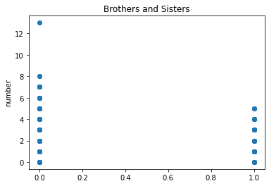

```python
plt.scatter(data["college"],data["brothersandsisters"])
plt.title('Brothers and Sisters')
plt.ylabel('number')
```

가로축은 대학 진학 여부, 세로축은 형제자매 수입니다.이 그래프를 보면 형제자매 수가 많을수록 대학 진학 가능성이 낮다는 것을 직관적으로 알 수 있다.

### 2.두 번째 2sls

```python
from statsmodels.sandbox.regression.gmm import IV2SLS


X = data["college"]
X = sm.add_constant(X)
Y = data['married']
I = data["after"]
I = sm.add_constant(I)

resultIV = IV2SLS(Y,X,I).fit()
resultIV.predict()
print(resultIV.summary())
```

```
                          IV2SLS Regression Results
==============================================================================
Dep. Variable:                married   R-squared:                      -6.935
Model:                         IV2SLS   Adj. R-squared:                 -6.939
Method:                     Two Stage   F-statistic:                     1.564
                        Least Squares   Prob (F-statistic):              0.211
Date:                Sat, 18 Dec 2021
Time:                        11:14:11
No. Observations:                1869
Df Residuals:                    1867
Df Model:                           1
==============================================================================
                 coef    std err          t      P>|t|      [0.025      0.975]
------------------------------------------------------------------------------
const          1.2314      0.244      5.043      0.000       0.752       1.710
college       -1.9910      1.592     -1.251      0.211      -5.113       1.131
==============================================================================
Omnibus:                      492.354   Durbin-Watson:                   1.570
Prob(Omnibus):                  0.000   Jarque-Bera (JB):             1002.451
Skew:                           1.562   Prob(JB):                    2.09e-218
Kurtosis:                       4.765   Cond. No.                         2.85
==============================================================================
```

```python
import matplotlib.pylab as plt # 导入绘图包
import matplotlib.pyplot as mp
```

```python
from google.colab import files
files.upload()
```

```
Saving grahp2.csv to grahp2.csv
```

```
{'grahp2.csv': b'1998,571,7.8\r\n1999,575,7.1\r\n2000,595,8\r\n2001,681,7.5\r\n2002,770,8.3\r\n2003,800,9.5\r\n2004,827,10.1\r\n2005,839,10.4\r\n2006,847,11.6\r\n2007,830,13\r\n2008,886,9\r\n'}
```

```python
gh=pd.read_csv("grahp2.csv",index_col=None,encoding='utf-8')
gh.tail()
```

|  | 1998 | 571 | 7.8 |
| --- | --- | --- | --- |
| 5 | 2004 | 827 | 10.1 |
| 6 | 2005 | 839 | 10.4 |
| 7 | 2006 | 847 | 11.6 |
| 8 | 2007 | 830 | 13.0 |
| 9 | 2008 | 886 | 9.0 |

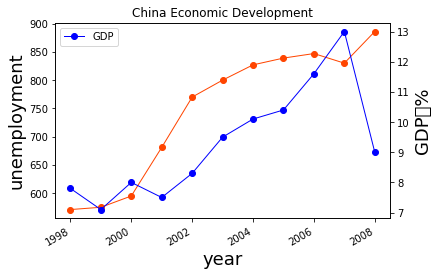

```python
dates,unemployment = np.loadtxt('grahp2.csv', delimiter=',', usecols=(0,1), unpack=True,encoding='utf-8')
dates,GDP = np.loadtxt('grahp2.csv', delimiter=',', usecols=(0,2), unpack=True)

mp.gcf().set_facecolor(np.ones(3) * 240/255)#设置背景色
fig, ax1 = plt.subplots() # 使用subplots()创建窗口
ax2 = ax1.twinx() # 创建第二个坐标轴
ax1.plot(dates, unemployment,'o-', c='orangered',label='unemployment', linewidth = 1) #绘制折线图像1,圆形点，标签，线宽
ax2.plot(dates, GDP, 'o-', c='blue',label='GDP', linewidth = 1) #同上
mp.legend(loc=1)

plt.title('China Economic Development')
ax1.set_xlabel('year',size=18) #与原始matplotlib设置参数略有不同，使用自己下载的中文宋体，参数位置不可改变
ax1.set_ylabel('unemployment',size=18)
ax2.set_ylabel('GDP：%',size=18)
mp.gcf().autofmt_xdate()#自动适应刻度线密度，包括x轴，y轴


mp.legend()#显示折线的意义
plt.show()
```

## 4.깊은 연구

이어 1980,1981년생으로 교육개혁을 경험한 사람과 그렇지 않은 사람의 차이가 대학에 간 소인인지, 경제적 소인인지 따져봐야 한다.2002년, 2003년, 2004년 공부에 중국 경제가 크게 변화있었냐, 그 변화의 효과 안에서 대학을 다녔는지, 중국 경제가 좋아졌는지 나빠졌는지를 알 수 있다.2002년부터 2004년까지 경제가 크게 성장한 것은 교육개혁과 관련이 깊지만 실업자가 크게 늘고 있는 것은 인재시장이 포화되기 시작한 탓인지 좀 더 깊이 연구해 보겠다.